# Experimentalphysik V

- [Inhaltsverzeichnis](https://uebungen.physik.uni-heidelberg.de/vorlesung/20172/pep5/toc)

# 1 Molekülbindung

## 1.1 Kovalente Bindung

$$\begin{equation}
E_g = K + A\\
E_\omega = K - A\\
\end{equation}$$

(K: klassische Wechselwirkung, A: Austausch Wechselwikrung)

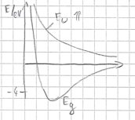

Kovalente Bindung

## 1.2 Hybridisierung

$$\begin{equation}
1s^2 2s^2 2p_x 2p_y \xrightarrow{\text{kostet Energie}} 1s^2 2s 2p_x 2p_y 2p_z
\end{equation}$$

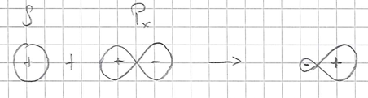

Orbitalhybridisierung in eine Raumrichtung

# 2 Molekülanregungen

$$\begin{equation}
E_{el} > E_{vib} > E_{rot}
\end{equation}$$

## 2.1 Rotationsspektrum

$$\begin{equation}
E_{rot} = \frac 1 2 I \omega^2 = \frac{L}{2I}
\end{equation}$$

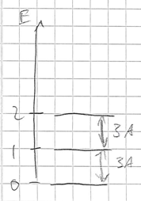

Rotationsenergie Niveaus

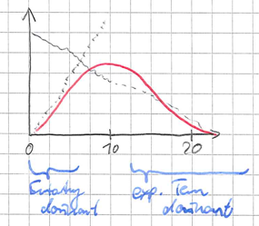

therm Entartung der Rotationsenergie

## 2.2 Vibrationsanregungen

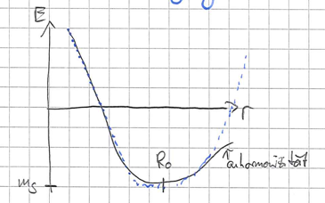

$$\begin{align}
E_{vib} =& \hbar\omega (v + \frac 12),\quad v:\text{ Vibrationsquantenzahl}\\
\omega =& \sqrt{\frac k \mu}, \qquad k:\text{ Bindungskonstante [$10^2$ N/m]}
\end{align}$$

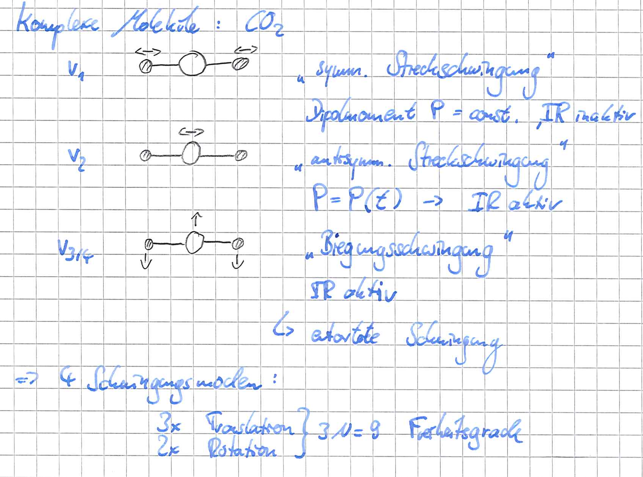

Vibrationen in $CO_2$

### 2.2.1 Raman-Streuung

(inelestische Streuung unter Vibrationsmodenanregung)

$$\begin{align}
E =& E_0 \cos(\omega_0 t)\\
\Rightarrow P(t) =& \alpha E_0 \cos(\omega_0 t)
\end{align}$$

falls sich bei Struungen $\alpha$ ändert, koppeln die Schwingungsmoden

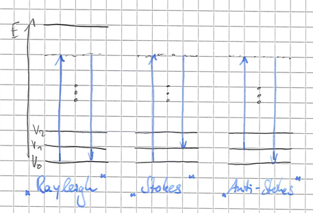

Klassifizierung der Streuung

$$\begin{align}
\alpha(R) =& \alpha(R_0) + \partial_R(\alpha)(R-R_0) + \cdots\\
R(t) =& R_0 + q \cos(\omega_0 t)
\end{align}$$

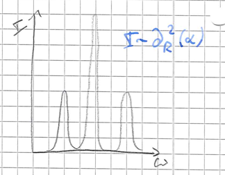

Schema eines Intensitätsspektrums bei Ramanstreuung

```
(Rotations-Raman-Spektrum?)
```

## 2.3 Elektronische Anregung

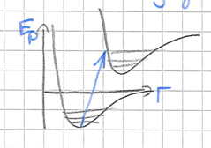

Lichtabsorption

- keine Zentralsymmetrie
- Entartungen “teilweise” aufgehoben
- axiale Feldsymmetrie entlang der Kernverbindungslinie
- $l_Z = m_Z\hbar\quad \in \mathbb Z$
- $s,p,d,f \rightarrow \sigma, \pi, \delta, \varphi$

# 3 Bindungen im Festkörper

$$\begin{align}
dF =& dE - TdS\\
E_{\text{Bind}} =& (\text{Gesamtenergie des FK}) - (\text{Summe der Energieen aller Atome})
\end{align}$$

## 3.1 Van-der-Waals Kristalle

- $\propto\frac{1}{r^6}$

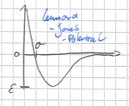

- $r_0=1.12\sigma$
- $E_B \approx 0.02-0.2$ eV

## 3.2 Ionen Bindung

- Elektrostatisch, Ionen mit abgeschl. Schalen
  $$\begin{align}
  U_B =& -\frac{e^2}{4\pi \epsilon_0 R_0}\\
  E_\text{Bind} =& (E_B \text{ der Ionen}) - (E_B: e^- \leftrightarrow Cl) + (E_{ion}: Na)
  \end{align}$$

> Erjen-Zellen?

## 3.3 kovalente Bindung

> ????

## 3.4 Metallische Bindung

- $E_{kin}$ der $e^-$
- $E_{Coulomb}$
- unidirektional

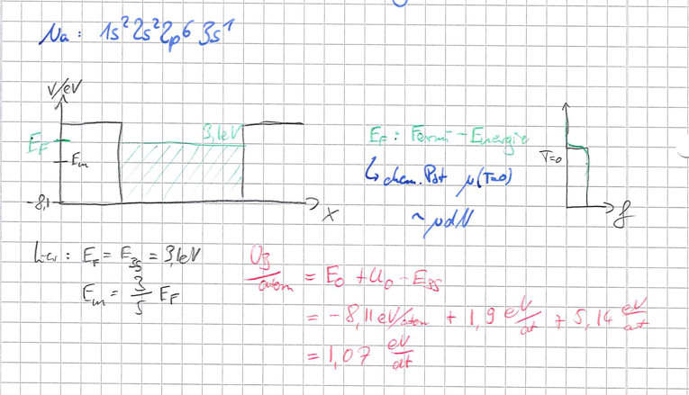

Rechenbeispiel an Na

## 3.5 Wasserstoff-Brücken Bindung

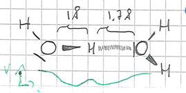

H-Brücke

# 4 Struktur und Strukturbestimmung

## 4.1 Kristallstrukturen

> **Kristall**: wohldef, langreichweitige geordnete Anordnung von Atomen (/ der Gleichgewichtspositionen)

> **amorphe FK**: keine Fernordnung, aber kurzreichweitige Ordnung
- Punktgitter:
  $$\begin{align}
  \vec R =n_1\vec{a_1}+n_2\vec{a_2}+n_3\vec{a_3}, \qquad (n_i\in\mathbb Z_0)
  \end{align}$$
- Translationssymmetrisch:

  $$\begin{align}
  \text{invariant unter } U(\vec r) = U(\vec r + \vec R), \qquad\forall \vec r \in \vec R
  \end{align}$$
- Einheitszelle: Raumelement, das den ges. Raum abdecken kann
- Primitive EZ: EZ mit nur einem Gitterpunkt

$\Rightarrow$ eine mögliche Konstruktion:

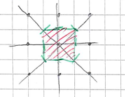

Wigner-Seitz-Zelle

## 4.2 -

## 4.3 Strukturbestimmung in Kristallen

> Bragg-Bedingung: $2d\sin\Theta = n\lambda$

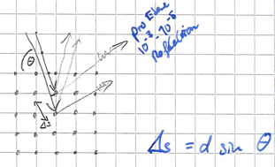

> Bragg Reflektion

Ebene Welle: $\Psi_k(\vec r) = \Psi_0 e^{i\vec k \vec r}$

### 4.3.1 Reziprokes Gitter

> für welche Wellenvektoren, hat $\Psi$ die Periodizität des Gitters?

**Definition**: Alle Vektoren $\vec G$ mit $e^{i\vec G\vec R}=1$ bilden das zum durch $\vec R$ aufgespannte Bravais-Gitter,

$\Leftrightarrow$ “**reziprokes Gitter**”

- reziproke Gitter eines Bravaisgitters ist ein Bravaisgitter
- reziproke eines reziproken Gitters ist identisch
- Länge der reziproken Gitter ist proportional zu $\frac{1}{\text{L\"ange der orig. Gittervektoren}}$
> 1. Billouin-Zone: Wigner-Seitz-Zelle des reziproken Gitters

### 4.3.2 Gitterebenen und Millerindizes

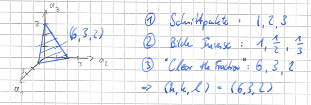

Miller-Indize Konstruktion

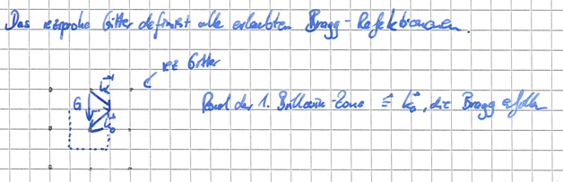

Reflektion

### 4.3.3 Ewald Konstruktion

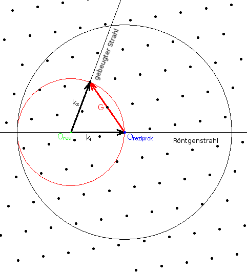

Ewaldkugel Konstruktion [Quelle: Wikipedia]

# 5 Gitterdynamik

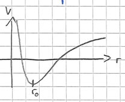

Gleichgewichtsabstände durch chemische Bindungen geg. durch:

- *adiabatische Näherung*: $e^-$ befinden sich im Grundzst., der durch die aktuelle Position der Rümpfe geg. ist
- *harmonische Näherung*: Wärmekapazität $c_p=T\partial_TS|_P$
- *anharmonische Effekte*: therm. Ausdehnung / Wärmeleitung

## 5.1 lineare Kette

$$\begin{align}
\text{Dispersionsrelation}\quad \omega=2\sqrt{\frac c m}|\sin(\frac{q a}{2})|
\end{align}$$

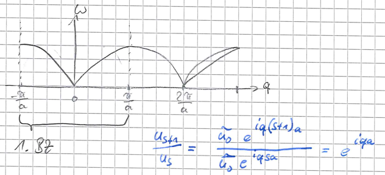

Dispersionsrelation im FK

## 5.2 zweiatomige lineare Kette

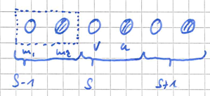

Schema

$$\begin{align}
\omega_{1,2}^2 = \frac c \mu \pm c\sqrt{\frac{1}{\mu^2}-\frac{4}{m_1 m_2}\sin^2(\frac{qa}{2})}
\end{align}$$

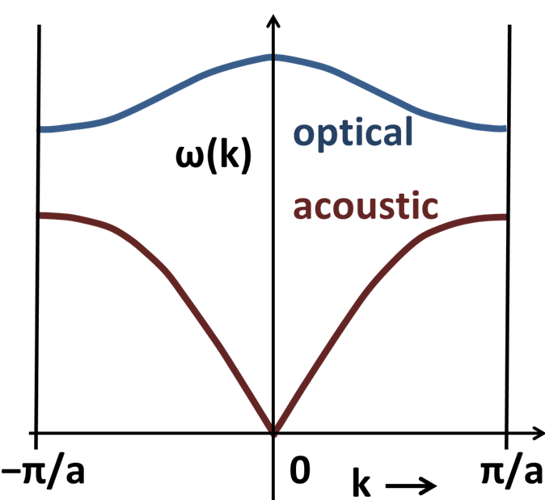

Akustische und Optische Moden

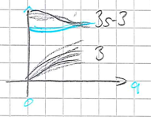

in 3D

## 5.3 Quantisierung von Gitterschwingungen / **Phononen**

$$\begin{align}
E_{\vec q,r}=(n_{\vec q,r}+\frac 12)\hbar \omega_r(\vec q)
\end{align}$$

Phonon: - $E=\hbar \omega$ - Boson - Quasiimpuls $\vec p=\hbar \vec q$ - 1 Phonon beteiligt alle Atome - $<n>=(e^{\frac{\hbar\omega}{v_gT}}-1)^{-1}$ - Impulserhaltung: $\hbar \vec q \pm \hbar \vec G$

## 5.4 Zustandsdichte

bisher: alle q erlaubt $\rightarrow$ jetzt: q diskret, durch feste/period. Randbed.

feste RB:
$$\begin{align}
\sin(qna) =& 0\\
\Rightarrow qNa =& p\pi\\
q =& \frac \pi L p, \qquad p\in\mathbb N_0, p \leq N
\end{align}$$

period. RB:
$$\begin{align}
e^{iqNa}=&1\\
q =& \frac{2\pi}{L}p, \qquad p\in\{ -\frac N 2, \frac N 2 \}\subset \mathbb Z
\end{align}$$

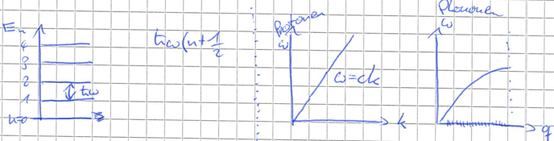

Phononen

unter der Näherung $\omega = vq$ (Debye)

$$\begin{align}
D(\omega) = \frac{V}{2\pi^2}\frac{\omega^2}{v^3}\approx\omega^2\qquad\text{Debye'sche Zustandsdichte}
\end{align}$$

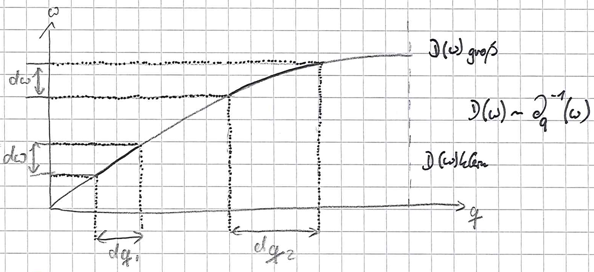

Debye’she Zustandsdichte

$$\begin{align}
k_B\Theta_D =& \hbar\omega_D&\text{Debye Temperatur}\\
w_D =& v q_D &\text{Debye Impuls}
\end{align}$$

## 5.5 Wärmekapazität des Kristallgitters

### 5.5.1 Debye Näherung

$$\begin{align}
c_v = \frac{12\pi^2}{5}Nk_B(\frac{T}{\Theta_D})^3\approx T^3
\end{align}$$

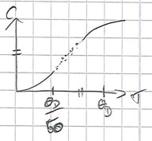

Verlauf von c

## 5.6 Zahl angeregter Phononen im Debye Modell

$$\begin{align}
T\leq\leq\Theta_D: && N_{Ph} \approx T^3\\
T\geq\Theta_D: && N_{Ph} \approx T
\end{align}$$

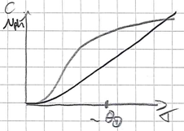

c/N vs T

## 5.7 Phononen-Wärmeleitung

$$\begin{align}
\vec{j_q} = -\kappa^{therm}\nabla T
\end{align}$$

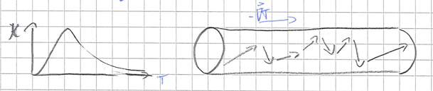

- Gastheorie als Analogie (+ Eindimensionalisierung)

$$\begin{align}
l=v\tau
\end{align}$$

- mittlere freie Weglange $l$, mittlere Stoßzeit $\tau$
- mittlerer Phononefluss in x-Richtung: $\frac12 nv_x$
- Wärmefluss $\vec{j_q}$:

$$\begin{align}
\vec{j_q} =& -n v_x^2cd_x(T)\tau\\
=& -\frac 13 c_v \Delta T vl(dx)^{-1}, \qquad nc = c_v
\end{align}$$

- Wärmeleitfähigkeit $\lambda$:

$$\begin{align}
\Rightarrow \lambda =& \frac 13 c_v\Delta T vl (dx)^{-1}
\end{align}$$

> Phonon-Phonon-Stoß